# Practical Machine Learning Course Project

# Introduction

The objective of this project is to identify the execution type of an exercise, using data from accelerometers on the belt, forearm, arm, and dumbell of 6 participants. The dataset includes readings from motion sensors on participants bodies. These reading will be used to classify the performed exercise into five categories: 1. exactly according to the specification (Class A) 2. throwing the elbows to the front (Class B) 3. lifting the dumbbell only halfway (Class C) 4. lowering the dumbbell only halfway (Class D) 5. throwing the hips to the front (Class E)

Please see the website ‘http://groupware.les.inf.puc-rio.br/har’ for more information.

# Getting the Data

```r
# Download and Read Data
download.file(trainUrl, destfile="./training.csv", method="curl")
download.file(testUrl, destfile="./testing.csv", method="curl")
```

# Read csv in Excel frist, and we can find some missiong values

```r
training <- read.csv("training.csv", na.strings =c("NA","#DIV/0!",""))
testing <- read.csv("testing.csv", na.strings =c("NA","#DIV/0!",""))
dim(training) # 19622   160
```

```
## [1] 19622   160
```

```r
dim(testing) #20 160
```

```
## [1]  20 160
```

# Cleaning Data(for training dataset)

```r
str(training)
```

```
## 'data.frame':    19622 obs. of  160 variables:
##  $ X                       : int  1 2 3 4 5 6 7 8 9 10 ...
##  $ user_name               : Factor w/ 6 levels "adelmo","carlitos",..: 2 2 2 2 2 2 2 2 2 2 ...
##  $ raw_timestamp_part_1    : int  1323084231 1323084231 1323084231 1323084232 1323084232 1323084232 1323084232 1323084232 1323084232 1323084232 ...
##  $ raw_timestamp_part_2    : int  788290 808298 820366 120339 196328 304277 368296 440390 484323 484434 ...
##  $ cvtd_timestamp          : Factor w/ 20 levels "02/12/2011 13:32",..: 9 9 9 9 9 9 9 9 9 9 ...
##  $ new_window              : Factor w/ 2 levels "no","yes": 1 1 1 1 1 1 1 1 1 1 ...
##  $ num_window              : int  11 11 11 12 12 12 12 12 12 12 ...
##  $ roll_belt               : num  1.41 1.41 1.42 1.48 1.48 1.45 1.42 1.42 1.43 1.45 ...
##  $ pitch_belt              : num  8.07 8.07 8.07 8.05 8.07 8.06 8.09 8.13 8.16 8.17 ...
##  $ yaw_belt                : num  -94.4 -94.4 -94.4 -94.4 -94.4 -94.4 -94.4 -94.4 -94.4 -94.4 ...
##  $ total_accel_belt        : int  3 3 3 3 3 3 3 3 3 3 ...
##  $ kurtosis_roll_belt      : num  NA NA NA NA NA NA NA NA NA NA ...
##  $ kurtosis_picth_belt     : num  NA NA NA NA NA NA NA NA NA NA ...
##  $ kurtosis_yaw_belt       : logi  NA NA NA NA NA NA ...
```

[output cut: 86 more lines]

As we can observe from the structure of training dataset, there are a lot of NAs and unique values in several variables.

## Step 1: Remove all the zero and near-zero predictors

We use nearZeroVar function to identify zero and near-zero predictors, and then apply a quick and dirty solution: throw these data away.

Note: We are assuming that all those predictors are non-informative, which is not necessarily true.

```r
# saveMetrics =TRUE will return data frame instead of index
nzVal <- nearZeroVar(training, saveMetrics = TRUE)
nzValPredictor <- row.names(nzVal[nzVal$nzv == TRUE | nzVal$zeroVar == TRUE, ])
nzValIdx <- which(colnames(training) %in% nzValPredictor)
training1 <- training[ ,-nzValIdx]
dim(training1) # 19622   124
```

```
## [1] 19622   124
```

## Step 2: Remove columns which has equal or more than 60% NAs

```r
threshold <- 0.6
naPredictorIdx <-c()
for (i in 1:ncol(training1)) {
        if (sum(is.na(training1[ , i])) / nrow(training1) >= threshold){
        naPredictorIdx <-c(naPredictorIdx, i)
        }
}
str(naPredictorIdx)  # 130
```

```
##  int [1:65] 11 12 13 14 15 16 17 18 19 20 ...
```

```r
trainingCleaned <- training1[ ,-naPredictorIdx]
dim(trainingCleaned) # 19622 59
```

```
## [1] 19622    59
```

## Step 3: Remove first to fifth column

```r
trainingCleaned <- trainingCleaned[ ,-(1:5)]
dim(trainingCleaned) # 19622 54
```

```
## [1] 19622    54
```

# Cleaning Data(for testing dataset) by the same process

## Step 1: Remove all the zero and near-zero predictors

```r
nzVal <- nearZeroVar(testing, saveMetrics = TRUE)
nzValPredictor <- row.names(nzVal[nzVal$nzv == TRUE | nzVal$zeroVar == TRUE, ])
nzValIdx <- which(colnames(training) %in% nzValPredictor)
testing1 <- testing[ ,-nzValIdx]
dim(testing1) # 20   59
```

```
## [1] 20 59
```

## Step 2: Remove columns which has equal or more than 60% NAs

```r
threshold <- 0.6
naPredictorIdx <-c()
for (i in 1:ncol(testing1)) {
        if (sum(is.na(testing1[ , i])) / nrow(testing1) >= threshold){
        naPredictorIdx <-c(naPredictorIdx, i)
        }
}
str(naPredictorIdx)  # Null
```

```r
testingCleaned <- testing1
dim(testingCleaned) # 20 59
```

```
## [1] 20 59
```

## Step 3: Remove first to fifth columns

Because these data don’t make intuitive sense for prediction (`X, user_name, raw_timestamp_part_1, raw_timestamp_part_2, cvtd_timestamp`), which happen to be the first five variables

```r
testingCleaned <- testingCleaned[ ,-(1:5)]
dim(testingCleaned) # 20 54
```

```
## [1] 20 54
```

# Data Splitting Method to estimate model accuracy

Data splitting involves partitioning the data into an explicit training dataset used to prepare the model and an unseen test dataset used to evaluate the models performance on unseen data.

It is useful when we have a very large dataset so that the test dataset can provide a meaningful estimation of performance, or for when we are using slow methods and need a quick approximation of performance.

The R code below splits the trainingCleaned dataset so that 60% is used for training a Decision Tree model/Random Forest Model, and 40% is used to evaluate the models performance.

## 1.Partition the training data into two data sets, 60% is train, 40% is test.

```r
# define an 60%/40% train/test split of the trainingCleaned dataset
set.seed(123)
inTrain <- createDataPartition(y = trainingCleaned$classe, p=0.6, list=FALSE)
train <- trainingCleaned[inTrain, ]
test <- trainingCleaned[-inTrain, ]
dim(train) # 11776    54
```

```
## [1] 11776    54
```

```r
dim(test) # 7846   54
```

```
## [1] 7846   54
```

## 2.Build Decision Tree Model to predict “classe”

Note: column “X” only contains id number, so exclude column “X” when build ML model

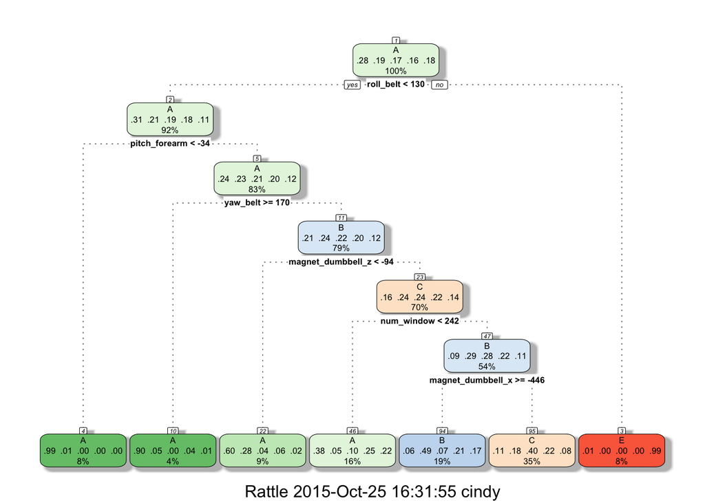

```r
# train a decision tree model
dtModel <- train(classe ~ .,data = train,method ="rpart")
fancyRpartPlot(dtModel$finalModel)
```

```r
# make predictions
predictions <- predict(dtModel, newdata = test)
# summerize results
confusionMatrix(predictions, test$classe)
```

```
## Confusion Matrix and Statistics
##
##           Reference
## Prediction    A    B    C    D    E
##          A 1814  316  145  363  329
##          B  107  706  113  282  272
##          C  303  496 1110  641  204
##          D    0    0    0    0    0
##          E    8    0    0    0  637
##
## Overall Statistics
##
##                Accuracy : 0.5438
##                  95% CI : (0.5327, 0.5549)
##     No Information Rate : 0.2845
##     P-Value [Acc > NIR] : < 2.2e-16
##
##                   Kappa : 0.4149
##  Mcnemar's Test P-Value : NA
##
## Statistics by Class:
##
##                      Class: A Class: B Class: C Class: D Class: E
## Sensitivity            0.8127  0.46509   0.8114   0.0000  0.44175
## Specificity            0.7946  0.87769   0.7462   1.0000  0.99875
## Pos Pred Value         0.6114  0.47703   0.4031      NaN  0.98760
## Neg Pred Value         0.9143  0.87245   0.9493   0.8361  0.88821
## Prevalence             0.2845  0.19347   0.1744   0.1639  0.18379
## Detection Rate         0.2312  0.08998   0.1415   0.0000  0.08119
## Detection Prevalence   0.3782  0.18863   0.3510   0.0000  0.08221
## Balanced Accuracy      0.8037  0.67139   0.7788   0.5000  0.72025
```

## 3. Build Random Forest Model to predict “classe”

```r
# train a random forest model
rfModel <- randomForest(classe ~ ., data = train)
# make predictions
predictions <- predict(rfModel, newdata = test)
# summerize results
confusionMatrix(predictions, test$classe)
```

```
## Confusion Matrix and Statistics
##
##           Reference
## Prediction    A    B    C    D    E
##          A 2232    2    0    0    0
##          B    0 1514    6    0    0
##          C    0    2 1359    6    0
##          D    0    0    3 1280    3
##          E    0    0    0    0 1439
##
## Overall Statistics
##
##                Accuracy : 0.9972
##                  95% CI : (0.9958, 0.9982)
##     No Information Rate : 0.2845
##     P-Value [Acc > NIR] : < 2.2e-16
##
##                   Kappa : 0.9965
##  Mcnemar's Test P-Value : NA
##
## Statistics by Class:
##
##                      Class: A Class: B Class: C Class: D Class: E
## Sensitivity            1.0000   0.9974   0.9934   0.9953   0.9979
## Specificity            0.9996   0.9991   0.9988   0.9991   1.0000
## Pos Pred Value         0.9991   0.9961   0.9941   0.9953   1.0000
## Neg Pred Value         1.0000   0.9994   0.9986   0.9991   0.9995
## Prevalence             0.2845   0.1935   0.1744   0.1639   0.1838
## Detection Rate         0.2845   0.1930   0.1732   0.1631   0.1834
## Detection Prevalence   0.2847   0.1937   0.1742   0.1639   0.1834
## Balanced Accuracy      0.9998   0.9982   0.9961   0.9972   0.9990
```

Thus, next we will use Cross Validation method to reestimate decision tree model and random forest model.

# Cross Validation Method to estimate model accuracy

## 1. k-fold Cross Validation for decision tree model

The k-fold cross validation method involves splitting the dataset into k-subsets. For each subset is held out while the model is trained on all other subsets. This process is completed until accuracy is determine for each instance in the dataset, and an overall accuracy estimate is provided.

It is a robust method for estimating accuracy, and the size of k and tune the amount of bias in the estimate, with popular values set to 3, 5, 7 and 10.

Here we will choose 5.

```r
# define training control
train_control <- trainControl(method="cv", number=5)
# train the decision tree model using trainingCleaned data
dtmodelCV <- train(classe~., data=trainingCleaned, trControl=train_control, method="rpart")
# make predictions
predictions <- predict(dtModel, newdata = trainingCleaned[ ,-54])
# summerize results
confusionMatrix(predictions, trainingCleaned$classe)
```

```
## Confusion Matrix and Statistics
##
##           Reference
## Prediction    A    B    C    D    E
##          A 4556  744  382  903  774
##          B  250 1795  270  741  657
##          C  760 1258 2770 1572  545
##          D    0    0    0    0    0
##          E   14    0    0    0 1631
##
## Overall Statistics
##
##                Accuracy : 0.548
##                  95% CI : (0.541, 0.5549)
##     No Information Rate : 0.2844
##     P-Value [Acc > NIR] : < 2.2e-16
##
##                   Kappa : 0.4204
##  Mcnemar's Test P-Value : NA
##
## Statistics by Class:
##
##                      Class: A Class: B Class: C Class: D Class: E
## Sensitivity            0.8165  0.47274   0.8095   0.0000  0.45218
## Specificity            0.8004  0.87880   0.7448   1.0000  0.99913
## Pos Pred Value         0.6191  0.48344   0.4012      NaN  0.99149
## Neg Pred Value         0.9165  0.87416   0.9487   0.8361  0.89008
## Prevalence             0.2844  0.19351   0.1744   0.1639  0.18382
## Detection Rate         0.2322  0.09148   0.1412   0.0000  0.08312
## Detection Prevalence   0.3750  0.18923   0.3519   0.0000  0.08383
## Balanced Accuracy      0.8084  0.67577   0.7771   0.5000  0.72565
```

## 2. k-fold Cross Validation for random forest model

```r
# define training control
train_control <- trainControl(method="cv", number=5)
# train the decision tree model using trainingCleaned data
rfmodelCV <- randomForest(classe~., data=trainingCleaned, trControl=train_control)
# make predictions
predictions <- predict(rfmodelCV, newdata = trainingCleaned[ ,-54])
# summerize results
confusionMatrix(predictions, trainingCleaned$classe)
```

```
## Confusion Matrix and Statistics
##
##           Reference
## Prediction    A    B    C    D    E
##          A 5580    0    0    0    0
##          B    0 3797    0    0    0
##          C    0    0 3422    0    0
##          D    0    0    0 3216    0
##          E    0    0    0    0 3607
##
## Overall Statistics
##
##                Accuracy : 1
##                  95% CI : (0.9998, 1)
##     No Information Rate : 0.2844
##     P-Value [Acc > NIR] : < 2.2e-16
##
##                   Kappa : 1
##  Mcnemar's Test P-Value : NA
##
## Statistics by Class:
##
##                      Class: A Class: B Class: C Class: D Class: E
## Sensitivity            1.0000   1.0000   1.0000   1.0000   1.0000
## Specificity            1.0000   1.0000   1.0000   1.0000   1.0000
## Pos Pred Value         1.0000   1.0000   1.0000   1.0000   1.0000
## Neg Pred Value         1.0000   1.0000   1.0000   1.0000   1.0000
## Prevalence             0.2844   0.1935   0.1744   0.1639   0.1838
## Detection Rate         0.2844   0.1935   0.1744   0.1639   0.1838
## Detection Prevalence   0.2844   0.1935   0.1744   0.1639   0.1838
## Balanced Accuracy      1.0000   1.0000   1.0000   1.0000   1.0000
```

# Select the best model to make testingCleaned dataset prediction

```r
# predict "classe" of testingCleaned data using nbmodelCV
predictionsDT <- predict(rfModel, newdata = testingCleaned)

# Apply the function given, to generate the file to submit
pml_write_files = function(x){
  n = length(x)
  for(i in 1:n){
    filename = paste0("problem_id_",i,".txt")
    write.table(x[i],file=filename,quote=FALSE,row.names=FALSE,col.names=FALSE)
  }
}

# create the file containing the results by the best model
pml_write_files(predictionsDT)
```